# Marketing Assignment 2

2021-02-22

Wilson McDermott, Sammantha Patil, and Oluwafemi Fabiyi with code from Anish Gera

```r
#install.packages("conjoint")
library(conjoint)
data(chocolate)
```

**Chocolate** is a dataset around chocolate. The variables used in the conjoint analysis will be kind w/ 4 levels (milk,walnut, delicaties, dark), price w/ 3 levels(low, average, and high), packing w/ 2 levels (paperback vs. hardback),weight w/ 3 levels (light, middle, heavy) and calorie w/ 2 levels (little vs. much)

description of the data provided in data(chocolate):

**cpref** = Vector of preferences (ratings) only - length 1392 (87 respondents x each respondent shown 16 profiles=1392). **cprefm** = Matrix of preferences (87 respondents and 16 profiles). **cprof** = Matrix of profiles (5 attributes and 16 full profiles). **clevn** = Character vector of names for the attributes’ levels. **csimp** = Matrix of simulation profiles.

#### PART 1

Use journey or chocolate data from package conjoint. Perform the following analyses:

- Partworth estimation for all individuals separately
- Partworth estimation by combining all individual responses into an aggregate
- Partworth estimation by using linear mixed models. In this case, you should treat each individual as a separate group for defining the random effects
- Partworth estimation of the mixed effects models by using MCMChregress

```r
set.seed(225)

#Randomly selecting the holdout data for the test dataframe
holdout <- vector()

#Randomly assigning 1-16 to each of the survey respondents 16 profiles
for (x in 1:87){
  j <- sample(1:16)
  holdout <- c(holdout,j)}

# adding in a response id column to identify each respondent - each respondent has a preference rating for 16 profiles
respid<- vector()
for (x in 1:87){
  j <- rep(x,16)
  respid <- c(respid,j)}

#establishing an inital dataframe
cprof.full <- cprof

#adding in cprof an additional 86 times, so cprof is repeated 87 times in cprof.full

for (x in 1:86){
  cprof.full <- rbind(cprof.full,cprof)}

#creating a dataframe that includes all respondents with their 16 profiles and preferences stacked on top of each other.

full.data <- data.frame(cbind(cpref, holdout, cprof.full,respid))

#to randomly remove 2 profiles per respondent going to use the randomly generated holdout data and just take the profiles where the holdout is 3-16 for the train and the test is 1 and 2.

train.data <- full.data[full.data$holdout>2,]
test.data <- full.data[full.data$holdout<3,]
```

```r
#Model 1 - Individual Model
coeff <- matrix(nrow=87, ncol=6)
pred <- vector(mode="numeric")

#looping through individual lm models and taking the coefficients into a separate dataframe
for (i in 1:87)
  {
    inddata = train.data[train.data$respid == i,]

# Build LM model per Respondent  lm(pref~ ………(fill the blank))
  model_p1 = (lm(pref~kind+price+packing+weight+calorie,data=inddata))

# Store coefficient in ‘coeff’
  coeff[i,] = c(model_p1$coefficients)

# create pred.test variable  to predict the model on test.data[test.data$respid==i,]
  t1 = test.data[test.data[,"respid"]==i,]
  pred.test = t1[,3:7]
  model_p1_pred <- predict(model_p1, pred.test)
  pred <- append(pred, model_p1_pred)
}
# Write your code to run the individual lm models

  mse_part1 <- mean(test.data$pref-pred)^2
  mse_part1
```

```
## [1] 0.002094543
```

```r
#Model 2 - Aggregate Model

#running full lm on all respondents and profiles as this is an aggregate model
#all respondents have the same coefficients

## Building an Aggregate Model using all 87 consumers' data and performing one linear regression

#Conjoint(cpref,cprof,clevn)

model_p2 = (lm(pref~kind+price+packing+weight+calorie,data=train.data))
t1 = test.data[,3:7]
model_p2_pred <- predict(model_p2, t1)
mse_part2 <- mean(test.data$pref-model_p2_pred)^2
mse_part2
```

```
## [1] 0.03085488
```

```r
#Model 3 - Mixed Models Approach

require(lme4)
model_p3 <- lmer(pref~kind+price+packing+weight+calorie + (1+kind+price+packing+weight+calorie|respid), control=lmerControl(check.conv.singular = .makeCC(action = "ignore",  tol = 1e-4)), data=train.data)
model_p3_pred <- predict(model_p3, test.data)
mse_part3 <- mean(test.data$pref-model_p3_pred)^2


coef(model_p3)$respid
```

|  | (Intercept) | kind | price | packing | weight | calorie |
| --- | --- | --- | --- | --- | --- | --- |
| 1 | 6.31605189 | -0.6041433 | 0.8951495 | -0.0429524066 | -0.1235334777 | 1.60796256 |
| 2 | 3.78181144 | 0.6804771 | 0.7913288 | -0.0395663712 | -0.0169333226 | 1.15175959 |
| 3 | -1.05250874 | 2.6486307 | 0.5139981 | 0.0609029910 | 0.1509347203 | 1.12791646 |
| 4 | 5.04140303 | 1.2142040 | 0.0670848 | -0.0555137991 | 0.0569136786 | 0.17114112 |
| 5 | 2.58016800 | 1.1344329 | 0.6980303 | -0.0036153701 | 0.0229779082 | 1.22398440 |
| 6 | 4.93301776 | 1.3268193 | 0.1801399 | -0.0904963944 | 0.0611862652 | -0.04430306 |
| 7 | 0.62557669 | 2.3868674 | 0.1946894 | 0.0511207737 | 0.1439903334 | 0.82199157 |
| 8 | 9.18965225 | -0.7256465 | 0.5015791 | -0.1453905084 | -0.1155636262 | 0.42348520 |
| 9 | 4.63964330 | 0.8092644 | 0.4579919 | -0.0485801144 | 0.0077741800 | 0.72165647 |
| 10 | 3.41819125 | 1.6436040 | 0.1034098 | -0.0137130663 | 0.0892322958 | 0.42233876 |

[output cut: 77 more lines]

```r
#install.packages('MCMCpack')
require(MCMCpack)
model_p4 <- MCMChregress (fixed=pref~kind+price+packing+weight+calorie,random = ~1+kind+price+packing+weight+calorie, group = "respid", r=6, R=6*diag(6),data = train.data)
```

```
##
## Running the Gibbs sampler. It may be long, keep cool :)
##
## **********:10.0%
## **********:20.0%
## **********:30.0%
## **********:40.0%
## **********:50.0%
## **********:60.0%
## **********:70.0%
## **********:80.0%
## **********:90.0%
## **********:100.0%
```

```r
#finding the fixed effects by taking the mean of the 1,000 simulations

fixed.intercept = mean(model_p4$mcmc[1:1000,1])
fixed.kind = mean(model_p4$mcmc[1:1000,2])
fixed.price = mean(model_p4$mcmc[1:1000,3])
fixed.packing = mean(model_p4$mcmc[1:1000,4])
fixed.weight = mean(model_p4$mcmc[1:1000,5])
fixed.calorie = mean(model_p4$mcmc[1:1000,6])

model_p4_coeff <- matrix(nrow=87, ncol=6)

for (i in 1:87){
  #creating the variable name for the random effects, which are unique to respondent
  v1 = mean(model_p4$mcmc[,paste("b.(Intercept).",as.character(i),sep = '')])
  v2 = mean(model_p4$mcmc[,paste("b.kind.",as.character(i),sep = '')])
  v3 = mean(model_p4$mcmc[,paste("b.price.",as.character(i),sep = '')])
  v4 = mean(model_p4$mcmc[,paste("b.packing.",as.character(i),sep = '')])
  v5 = mean(model_p4$mcmc[,paste("b.weight.",as.character(i),sep = '')])
  v6 = mean(model_p4$mcmc[,paste("b.calorie.",as.character(i),sep = '')])

  #taking the mean of the individual variables to find the random effects and adding the fixed effects

  model_p4_coeff[i,1] = mean(v1) + fixed.intercept
  model_p4_coeff[i,2] = mean(v2) + fixed.kind
  model_p4_coeff[i,3] = mean(v3) + fixed.price
  model_p4_coeff[i,4] = mean(v4) + fixed.packing
  model_p4_coeff[i,5] = mean(v5) + fixed.weight
  model_p4_coeff[i,6] = mean(v6) + fixed.calorie
}

model_p4_coeff_test = rbind(model_p4_coeff[1,], model_p4_coeff[1,])

for (i in 1:87){
model_p4_coeff_test = rbind(model_p4_coeff_test,model_p4_coeff[i,],model_p4_coeff[i,])
}

#generating the predictions by looping through and multiplying by the coefficients

model_p4_pred <- numeric()

# How will you score the test profiles in MCMC ?

for (i in 1:174){
model_p4_pred[i] = model_p4_coeff_test[i,1] + model_p4_coeff_test[i,2]*test.data[i,3]+model_p4_coeff_test[i,3]*test.data[i,4]+model_p4_coeff_test[i,4]*test.data[i,5]+model_p4_coeff_test[i,5]*test.data[i,6]+model_p4_coeff_test[i,6]*test.data[i,7]
}

mse_part4 <- mean(test.data$pref-model_p4_pred)^2
mse_part4
```

```
## [1] 0.02141252
```

### Part 2: Assess performance of 1-4 in step (1) using 2 randomly selected profiles for each individual as “Holdout” profiles for each consumer. The winner should have the lowest error on the holdout profiles

#### Compare the performance of the 4 models

```r
data.frame(mse_part1,mse_part2,mse_part3,mse_part4)
```

| mse_part1 | mse_part2 | mse_part3 | mse_part4 |
| --- | --- | --- | --- |
| 0.002094543 | 0.03085488 | 0.00171089 | 0.02141252 |

Based on the four models, model 3 is the best based on MSE

### Part 3: Perform cluster analysis of each individual’s partworths to define Benefit segments. For this purpose, use the partworths from steps 1,3, or 4 that has the best predictions for the holdout data from step 2.

Now we will cluster the part-worths of the **best model - model three**.

```r
#install.packages('stats')
require(stats)

# Choose teh coefficient from the best model based on test data performance
partworths <- coef(model_p3)$respid
partworths
```

|  | (Intercept) | kind | price | packing | weight | calorie |
| --- | --- | --- | --- | --- | --- | --- |
| 1 | 6.31605189 | -0.6041433 | 0.8951495 | -0.0429524066 | -0.1235334777 | 1.60796256 |
| 2 | 3.78181144 | 0.6804771 | 0.7913288 | -0.0395663712 | -0.0169333226 | 1.15175959 |
| 3 | -1.05250874 | 2.6486307 | 0.5139981 | 0.0609029910 | 0.1509347203 | 1.12791646 |
| 4 | 5.04140303 | 1.2142040 | 0.0670848 | -0.0555137991 | 0.0569136786 | 0.17114112 |
| 5 | 2.58016800 | 1.1344329 | 0.6980303 | -0.0036153701 | 0.0229779082 | 1.22398440 |
| 6 | 4.93301776 | 1.3268193 | 0.1801399 | -0.0904963944 | 0.0611862652 | -0.04430306 |
| 7 | 0.62557669 | 2.3868674 | 0.1946894 | 0.0511207737 | 0.1439903334 | 0.82199157 |
| 8 | 9.18965225 | -0.7256465 | 0.5015791 | -0.1453905084 | -0.1155636262 | 0.42348520 |
| 9 | 4.63964330 | 0.8092644 | 0.4579919 | -0.0485801144 | 0.0077741800 | 0.72165647 |
| 10 | 3.41819125 | 1.6436040 | 0.1034098 | -0.0137130663 | 0.0892322958 | 0.42233876 |

[output cut: 77 more lines]

```r
#install.packages('purrr')
require(purrr)
```

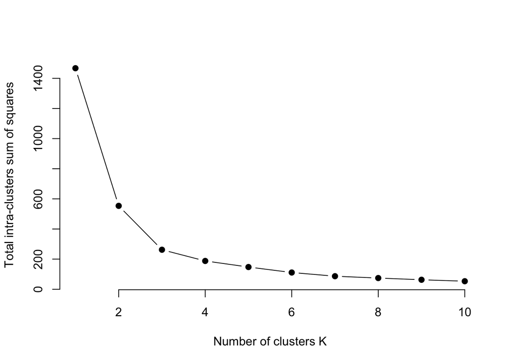

```r
set.seed(123)
# function to calculate total intra-cluster sum of square
iss <- function(k) {
  kmeans(partworths,k,iter.max=100,nstart=100)$tot.withinss
}
k.values <- 1:10

iss_values <- map_dbl(k.values, iss)

plot(k.values, iss_values,
    type="b", pch = 19, frame = FALSE,
    xlab="Number of clusters K",
    ylab="Total intra-clusters sum of squares")
```

```r
# Perform Clustering

Clusters = kmeans(partworths,3,iter.max=100,nstart=100)
Prefs = Clusters$centers
colnames(Prefs) = c('Intercept','kind', 'price', 'packing', 'weight', 'calorie')
Prefs
```

```
##   Intercept      kind     price    packing      weight   calorie
## 1  8.879670 -1.014807 0.7167207 -0.1246087 -0.14798001 0.8865944
## 2 -1.019287  2.209564 0.6386678  0.1005279  0.11040056 1.7057310
## 3  3.246071  1.141882 0.5499663 -0.0204234  0.03007313 0.9420341
```

```r
#Attribute importance can be observed above from the coefficients for each cluster
```

### Part 4: Build a simulator that takes as input 4 or 5 input concepts, and produces market share estimates. Function caLogit can be used from package conjoint

Build a simulator that takes as input 4 or 5 input concepts, and produces market share estimates. Function caLogit can be used from package conjoint.

```r
#First, we build a dataframe of the profiles we want to use as inputs (calling this dataframe 'csimp0').

csimp0 = csimp[sample(nrow(csimp)),]
colnames(csimp0) = c('kind', 'price', 'packing', 'weight', 'calorie')
#Here we can see what the dataframe looks like.
print(csimp0)
```

```
##   kind price packing weight calorie
## 1    4     1       2      2       1
## 4    3     1       1      1       1
## 2    1     3       1      1       2
## 3    2     2       1      3       1
```

```r
#Then we run caLogit using 'csimp0' as our matrix of simulation profiles, along with the cpref and cprof given in the chocolate data. These are the market share estimates.

simutil<-caLogit(csimp0,cpref,cprof)
print("Percentage participation of profiles:", quote=FALSE)
```

```
## [1] Percentage participation of profiles:
```

```r
print(simutil)
```

```
## [1] 49.81532 12.32256 25.20706 12.65507
```

```r
ShowAllSimulations(csimp0,cpref,cprof)
```

```
##   TotalUtility MaxUtility BTLmodel LogitModel
## 1        10,41      52,87    31,39      49,82
## 2         6,35      12,64    19,01      12,32
## 3         8,50      22,99    26,43      25,21
## 4         7,39      11,49    23,17      12,66
```

```r
clusterone = Prefs[1,]
clustertwo = Prefs[2,]
clusterthree = Prefs[3,]

clusteronecentroids = clusterone[2:6]
mat = cprof * matrix(rep(clusteronecentroids, NROW(cprof)), nrow = NROW(cprof), byrow = TRUE)

rating = vector(mode ="numeric")
for (i in 1:16){
  t = (sum(mat[i,]) + clusterone[1])
  rating = append(rating, t)
}
clusterOneRatings = cbind(cprof, rating)

clusterOneRatingsFinal = clusterOneRatings[with(clusterOneRatings, order(-rating)),]
clusterOneRatingsFinal[1:5,]
```

|  | kind | price | packing | weight | calorie | rating |
| --- | --- | --- | --- | --- | --- | --- |
| 11 | 1 | 3 | 2 | 1 | 2 | 11.391016 |
| 6 | 1 | 1 | 2 | 2 | 2 | 9.809595 |
| 12 | 2 | 2 | 1 | 1 | 2 | 9.784097 |
| 8 | 1 | 2 | 1 | 3 | 1 | 9.616350 |
| 14 | 1 | 1 | 1 | 1 | 1 | 9.195589 |

```r
clustertwocentroids = clustertwo[2:6]
mat = cprof * matrix(rep(clustertwocentroids, NROW(cprof)), nrow = NROW(cprof), byrow = TRUE)

rating = vector(mode ="numeric")
for (i in 1:16){
  t = (sum(mat[i,]) + clustertwo[1])
  rating = append(rating, t)
}
clusterTwoRatings = cbind(cprof, rating)

clusterTwoRatingsFinal = clusterTwoRatings[with(clusterTwoRatings, order(-rating)),]
clusterTwoRatingsFinal[1:5,]
```

|  | kind | price | packing | weight | calorie | rating |
| --- | --- | --- | --- | --- | --- | --- |
| 7 | 4 | 3 | 1 | 1 | 2 | 13.35736 |
| 15 | 4 | 1 | 1 | 3 | 2 | 12.30083 |
| 5 | 4 | 2 | 2 | 2 | 1 | 11.22389 |
| 2 | 3 | 2 | 2 | 1 | 2 | 10.60966 |
| 4 | 4 | 1 | 2 | 1 | 1 | 10.47483 |

```r
clusterthreecentroids = clusterthree[2:6]
mat = cprof * matrix(rep(clusterthreecentroids, NROW(cprof)), nrow = NROW(cprof), byrow = TRUE)

rating = vector(mode ="numeric")
for (i in 1:16){
  t = (sum(mat[i,]) + clusterthree[1])
  rating = append(rating, t)
}
clusterThreeRatings = cbind(cprof, rating)

clusterThreeRatingsFinal = clusterThreeRatings[with(clusterThreeRatings, order(-rating)),]
clusterThreeRatingsFinal[1:5,]
```

|  | kind | price | packing | weight | calorie | rating |
| --- | --- | --- | --- | --- | --- | --- |
| 7 | 4 | 3 | 1 | 1 | 2 | 11.357215 |
| 15 | 4 | 1 | 1 | 3 | 2 | 10.317429 |
| 5 | 4 | 2 | 2 | 2 | 1 | 9.874864 |
| 2 | 3 | 2 | 2 | 1 | 2 | 9.644943 |
| 1 | 3 | 3 | 1 | 2 | 1 | 9.303372 |